# Reliability and Multi-Group CFA analysis

Anne-Flore Cabouat

2024-03-12

## Librairies

```r
library(dplyr)
```

```r
library(knitr) #RStudio
library(png) #output png
library(corrplot) #plot correlation matrix
library(misty) #Little's test for MCAR
library(mice)
library(mifa) # MICE for missing data handling
library(lavaan) # for cfa
library(psych) # for EFA
library(RColorBrewer) #for corr matrix
```

## Functions

```r
make_corrM <- function(d, order = NULL, nb_fa = 4){

  if (anyNA(d)){
  # Multiple imputation using Fully Conditional Specification (FCS) implemented by the MICE algorithm as described in Van Buuren and Groothuis-Oudshoorn (2011) doi:10.18637/jss.v045.i03
  #run MICE and generate covariance matrix with with mifa package
  mi <- invisible(mifa(
  data      = d,
  n_pc      = nb_fa, #factors estimates
  ci        = "fieller", #confidence interval method
  print     = FALSE,
  m = 5 #number of MICE iterations
  ))

  corr_MICE <- cov2cor(mi$cov_combined)

  if (length(order)>0){
    corrM_reorder <- corr_MICE[order, order]
    corr_MICE <- corrM_reorder
  }

  # corrM <- corFiml(d)
  return(corr_MICE)} else {
    return(cor(d))
  }
}

# Applicability of EFA

## Bartlett test of sphericity - from TH
bartlettTest <- function(corrMatrix,data){
  bart <- cortest.bartlett(corrMatrix, n = nrow(data))
  if(bart[2]>0.05) cat("WARNING the p value is above 0.05") else cat("The p value is below 0.05. We are good to continue.")
  cat("\n\n")
  print(bart)
  return(bart)
}

##KMO to complement Bartlett - from TH
KMOTest <- function(corrMatrix){
  kmo <- KMO(corrMatrix)
  cat(paste("The overall measure of sampling adequacy is: ",kmo[1]))
  cat("\n\n")
  if(kmo[1]<.7) cat("WARNING the sampling adequacy has dropped below 0.7") else cat("The sampling adequacy is above 0.7. We are generally good.")
  cat("\n\n")
  return(kmo)
}

# Missing values

missingTest <- function(na_percent, mcar_pvalue){
  if (na_percent<5 & mcar_pvalue<=.05){
      cat("Data is MCAR and less than 5% missing data, which is negligible. We are good to continue.")
  } else if (na_percent<5 & mcar_pvalue>.05){
      cat("Data is NOT MCAR but less than 5% missing data, which is negligible. We are good to continue.")
  } else if(na_percent>=5 & mcar_pvalue>.05) {
      cat("WARNING missing data is not negligible (> 5%) AND missing data is NOT MCAR. Further investigation is needed.")
    }else if (na_percent>=5 & na_percent<40 & mcar_pvalue<=.05){
      cat("Data is MCAR but more than 5% missing data. Use imputation / likelihood methods.")
    }  else {
      cat("40% or more missing data and / or something is wrong.")
    }}


# Parallel analysis for each group

parallelAnalysis <- function(corrMatrix, observations = nrow(the_data), file_suffix){
  pdf(paste(paste("generatedPlots-CFA/ScreePlot-",file_suffix,sep=""),'.pdf'), width=8, height=4)
  parallel <- fa.parallel(corrMatrix, n.obs=observations, fa="fa", n.iter=100, main="Scree plots with parallel analysis", error.bars = TRUE)
  print(parallel)
  dev.off()
  cat("\n\n")
}

stimulus_data_test <- function(the_data, the_letter){
  ## Here wwe run test on the data
  ### Shapiro Wilk’s test (P-values < 0.05 indicate not normal)
  cat(paste("\n=================\n NORMALITY in", the_letter, "\n"))

  cat(paste("\n #### Shapiro in", the_letter, "\n"))
  mapply(shapiro.test, the_data)

  ### Multivariate normality
  # To say the data are multivariate normal:
  # • z-kurtosis < 5 (Bentler, 2006) and the P-value should be ≥ 0.05.
  # • the plot should also form a straight line (Arifin, 2015).

  cat(paste("\n #### Multivariate normality in", the_letter, "\n"))
  mardia(the_data)

  cat(paste("\n=================\n MISSING DATA IN in", the_letter, "\n"))
  ### Missing data

  if (anyNA(the_data)) {
  cat("#### Little's test for MCAR\n")
  #test MCAR
  MCAR <- na.test(the_data)
  mcar_p <- MCAR[["result"]][["pval"]]

  cat("\n#### Amount of missing data\n")
  nb_obs <- nrow(the_data)*ncol(the_data)
  na_amount <- sum(is.na(the_data))/nb_obs*100
  cat(paste(as.numeric(na_amount)), "% of data is missing\n\n")

  missingTest(na_amount, mcar_p)
  } else {
  cat("No missing values found in the_data.\n")
  }


### Multiple Imputation for missing values
  cat(paste("\n Multiple Imputation for missing values in", the_letter, "\n"))
  corr_M <- make_corrM(the_data, nb_fa = 4)

  cat(paste("\n=================\n FACTORABILITY in", the_letter, "\n"))

  ####  Bartlett’s test of sphericity
  # An objective test of the factorability of the correlation matrix is Bartlett’s (1954) test of sphericity, which statistically tests the hypothesis that the correlation matrix contains ones on the diagonal and zeros on the off-diagonals. Hence, that it was generated by random data. This test should produce a statistically significant chi-square value to justify the application of EFA.
  # If the p-value from Bartlett’s Test of Sphericity is lower than our chosen significance level (common choices are 0.10, 0.05, and 0.01), then our dataset is suitable for a data reduction technique.
  cat(paste("\n #### Bartlett in", the_letter, "\n"))
  bartlettTest(corr_M, the_data)

  ####  KMO
  # Large sample sizes make the Bartlett test sensitive to even trivial deviations from randomness, so its results should be supplemented with a measure of sampling adequacy. The Kaiser-Meyer-Olkin (KMO; Kaiser, 1974) measure of sampling adequacy is the ratio of correlations and partial correlations that reflects the extent to which correlations are a function of the variance shared across all variables rather than the variance shared by particular pairs of variables. KMO values range from 0.00 to 1.00 and can be computed for the total correlation matrix as well as for each measured variable.
  # - KMO values ≥.70 are desired
  # - KMO values ≤.50 are generally considered unacceptable
  cat(paste("\n #### KMO in", the_letter, "\n"))
  KMOTest(corr_M)



  parallelAnalysis(corr_M, observations=nb_obs, the_letter)

}

fitMeasures_output <- function(modelFit, model_name) {
  print(fitMeasures(modelFit, c("chisq", "df", "pvalue", "cfi", "rmsea"),
                  output = "text"), add.h0 = TRUE)

  fit_Indices <- fitMeasures(modelFit, output = "matrix")
  colnames(fit_Indices)[1] <- c(model_name)
  write.csv(fit_Indices,file=(paste("generatedData-CFA/fit_indices-", model_name, ".csv", sep="")))

  cat("\nDETAILS\n=================\n")
  print(fit_Indices)

  # cat("\n RMSEA - \n")
  # this_RMSEAIndices <- fit_Indices[c("rmsea","rmsea.pvalue","rmsea.ci.lower","rmsea.ci.upper","rmsea.ci.level")]
  # print(this_RMSEAIndices)
  #
  # cat("\n SRMR \n")
  # this_SRMRIndices <- fit_Indices[c("srmr")]
  # print(this_SRMRIndices)
  #
  # cat("\n Comparative Fit Index \n")
  # this_CFIIndices <- fit_Indices[c("cfi")]
  # print(this_CFIIndices)
  #
  # cat("\n Chi-square \n")
  # this_ChiSquareIndices <- fit_Indices[c("chisq","df","pvalue")]
  # print(this_ChiSquareIndices)

}

select_all_variables <- function (dataset, col_list) {
  dataset %>% select(all_of(unlist(col_list)))
}
```

## Multigroup CFA

https://lavaan.ugent.be/tutorial/groups.html

```r
#we retrieve our model from EFA conducted on all data

this_model <- "Tested_model"
## best items selected on reliability measures only
Readability_factors <- list(
  understand = list("obvious","represent","understandEasi"),
  layout = list("messi", "crowd","distract"),
  dataRead = list("inform","identifi","find"),
  dataFeat = list("visibl","see")
)


# Create a vector of column names to keep for the model with selected items
columns_to_keep <- unlist(Readability_factors)

# Function to convert a factor list to the required string format
factor_to_string <- function(factor_name, factor_list) {
  paste(factor_name, " =~ ", paste(factor_list, collapse = " + "))
}
```

## Load data

```r
stimuli_letters <- list("A","B","C")
grp_data <- read.csv(paste("multigroup_ratings.csv"), encoding="UTF-8")
data <- subset(grp_data, select = -c(stimulus))

# and make directories if needed

if (!dir.exists("generatedData-CFA/")) {
  dir.create("generatedData-CFA/", recursive = FALSE)
}

if (!dir.exists("generatedPlots-CFA/")) {
  dir.create("generatedPlots-CFA/", recursive = FALSE)
}
```

## Descriptive statistics - Check minimum/maximum values per item, and screen for missing values

```r
cat("\n\n==========================================\n
    ==========================================\n
    ==========================================\n")
cat("\n\n OVERVIEW \n\n")
```

```
##
##
##  OVERVIEW
```

```r
cat("==========================================\n
    ==========================================\n
    ==========================================\n\n")
describe(data)
```

```
##                vars   n   mean     sd median trimmed    mad min max range  skew
## X                 1 444 221.50 128.32  221.5  221.50 164.57   0 443   443  0.00
## crowd             2 444   3.56   2.21    3.0    3.45   2.97   1   7     6  0.34
## distract          3 444   3.98   2.08    4.0    3.97   2.97   1   7     6  0.03
## find              4 444   4.82   1.82    5.0    4.97   1.48   1   7     6 -0.60
## identifi          5 444   4.71   1.82    5.0    4.85   1.48   1   7     6 -0.53
## inform            6 444   4.63   1.90    5.0    4.77   1.48   1   7     6 -0.50
## messi             7 444   3.75   2.18    3.0    3.69   2.97   1   7     6  0.21
## obvious           8 444   5.04   1.72    6.0    5.23   1.48   1   7     6 -0.79
## represent         9 444   5.09   1.74    6.0    5.31   1.48   1   7     6 -0.89
## see              10 444   4.46   1.87    5.0    4.55   1.48   1   7     6 -0.32
## understandEasi   11 444   4.95   1.81    6.0    5.13   1.48   1   7     6 -0.75
## visibl           12 444   4.60   1.81    5.0    4.70   1.48   1   7     6 -0.45
##                kurtosis   se
## X                 -1.21 6.09
## crowd             -1.42 0.10
## distract          -1.41 0.10
## find              -0.79 0.09
## identifi          -0.87 0.09
## inform            -0.97 0.09
## messi             -1.47 0.10
## obvious           -0.38 0.08
## represent         -0.22 0.08
## see               -1.08 0.09
## understandEasi    -0.59 0.09
## visibl            -0.94 0.09
```

```r
response.frequencies(data)
```

```
##                         1          2          3          4          5         6
## crowd          0.23648649 0.20270270 0.13963964 0.04504505 0.08783784 0.1373874
## distract       0.15090090 0.15990991 0.16891892 0.07432432 0.11936937 0.1824324
## find           0.05630631 0.09459459 0.11711712 0.07882883 0.20270270 0.2567568
## identifi       0.06306306 0.09234234 0.13513514 0.08108108 0.20495495 0.2522523
## inform         0.08558559 0.08558559 0.14864865 0.06306306 0.19594595 0.2522523
## messi          0.20045045 0.18468468 0.15540541 0.05630631 0.08783784 0.1599099
## obvious        0.04504505 0.06756757 0.09459459 0.10810811 0.16891892 0.3108108
## represent      0.05180180 0.06306306 0.09459459 0.06531532 0.19594595 0.3130631
## see            0.07882883 0.10810811 0.15765766 0.09909910 0.19144144 0.2162162
## understandEasi 0.05855856 0.08333333 0.10135135 0.07432432 0.17567568 0.3018018
## visibl         0.06081081 0.11486486 0.12837838 0.08333333 0.23423423 0.2297297
##                        7 miss
## crowd          0.1509009    0
## distract       0.1441441    0
## find           0.1936937    0
## identifi       0.1711712    0
## inform         0.1689189    0
## messi          0.1554054    0
## obvious        0.2049550    0
## represent      0.2162162    0
## see            0.1486486    0
## understandEasi 0.2049550    0
## visibl         0.1486486    0
```

```r
nb_obs <- nrow(data)
cat("\n Sample size:")
```

```
##
##  Sample size:
```

```r
print(nb_obs)
```

```
## [1] 444
```

# Reliability

```r
cat("\n\n==========================================\n")
cat("==========================================\n")
cat("==========================================\n")
cat("\n \n CORRELATIONS \n \n")
```

```
##
##
##  CORRELATIONS
##
```

```r
cat("==========================================\n")
cat("==========================================\n")
cat("==========================================\n\n")
```

```r
#corr Matrix with selected items
data_reduced_factors <- data %>% select(all_of(columns_to_keep))

corrM <- make_corrM(data_reduced_factors, nb_fa = 4)

## as csv
write.csv(corrM, "generatedData-CFA/subscales-correlation.csv")

# as pdf
this_file <- "generatedPlots-CFA/subscales-corr.pdf"
pdf(this_file, height=15, width=15)
plot <- corrplot(corrM,
        # type = 'lower', #only lower half
        tl.srt = 30, #rotate text labels
        method="color",
        col = COL2('RdYlBu'),
        order="original",
        addrect = 4,
        tl.col="black", tl.cex = 1.3, # Text label color and size
        addCoef.col = "white", number.cex = 1, # Add coefficient of correlation and size
        )
dev.off()
```

```r
parallelAnalysis(corrM, observations=nb_obs, "All")
```

```
## Parallel analysis suggests that the number of factors =  4  and the number of components =  NA
## Call: fa.parallel(x = corrMatrix, n.obs = observations, fa = "fa",
##     main = "Scree plots with parallel analysis", n.iter = 100,
##     error.bars = TRUE)
## Parallel analysis suggests that the number of factors =  4  and the number of components =  NA
##
##  Eigen Values of
##
##  eigen values of factors
##  [1]  8.08  0.49  0.26  0.18 -0.06 -0.07 -0.11 -0.14 -0.17 -0.19 -0.21
##
##  eigen values of simulated factors
##  [1]  0.51  0.20  0.15  0.10  0.06  0.02 -0.02 -0.06 -0.10 -0.14 -0.20
##
##  eigen values of components
##  [1] 8.34 0.79 0.56 0.41 0.18 0.17 0.15 0.14 0.10 0.09 0.08
##
##  eigen values of simulated components
## [1] NA
```

```r
cat("\n\n==========================================\n")
cat("==========================================\n")
cat("==========================================\n")
cat("\n \n RELIABILITY \n \n")
```

```
##
##
##  RELIABILITY
##
```

```r
cat("==========================================\n")
cat("==========================================\n")
cat("==========================================\n\n")
#a function to create dfs with alpha and omega values
make_reliability_df <- function(this_data,
                                col_name,
                                row_suffix = "")
  {
  raw_alpha_name <- paste("raw_alpha",row_suffix, sep="")
  std_alpha_name <- paste("std.alpha",row_suffix, sep="")
  tot_omega_name <- paste("omega.tot",row_suffix, sep="")

  this_reliability_df <- data.frame(row.names = c(raw_alpha_name, std_alpha_name, tot_omega_name))

  alpha_values <- psych::alpha(this_data)
  cat("Alpha raw:")
  print(alpha_values$total$raw_alpha)
  print(alpha_values$total$std.alpha)


  nb_obs <- nrow(this_data)
  corrM <- make_corrM(this_data, nb_fa = 1)
  om <- omega(corrM, n.obs = nb_obs, 1) #https://personality-project.org/r/psych/HowTo/omega.pdf
  # summary(om)

  # Assign values directly to corresponding rows and columns in alpha_omega_df
  this_reliability_df[raw_alpha_name, col_name] <- alpha_values$total$raw_alpha
  this_reliability_df[std_alpha_name, col_name] <- alpha_values$total$std.alpha
  this_reliability_df[tot_omega_name,col_name] <- om$omega.tot

  print(print(colnames(this_reliability_df)))

  return(this_reliability_df)
}


reliability_metrics <- c("raw_alpha", "std.alpha", "omega.tot")

subscale_reliability_df <- data.frame(row.names = reliability_metrics)

row_names <- c()
for (letter in stimuli_letters) {
  row_names <- c(row_names, paste(reliability_metrics, "in", letter))
}


# Initialize subscale_group_reliability_df with row names and column names
subscale_group_reliability_df <- data.frame(matrix(nrow = length(row_names), ncol = length(names(Readability_factors))))
rownames(subscale_group_reliability_df) <- row_names
colnames(subscale_group_reliability_df) <- names(Readability_factors)

# subscale_group_reliability_df <- data.frame(row.names = c("raw_alpha in A",
#                                                           "std.alpha in A",
#                                                           "omega.tot in A",
#                                                           "raw_alpha in B",
#                                                           "std.alpha in B",
#                                                           "omega.tot in B",
#                                                           "raw_alpha in C",
#                                                           "std.alpha in C",
#                                                           "omega.tot in C"))
#
# colnames(subscale_group_reliability_df) <- names(Readability_factors)

for (factor in names(Readability_factors)){
  cat(paste("\n ======================\n Individual factor reliability on selected items for", this_model, "-", factor, "\n (omega and alpha) \n\n\n"))
  factor_data <- data %>% select(all_of(unlist(Readability_factors[[factor]])))

  subscale_reliability_df <- cbind(subscale_reliability_df, make_reliability_df(factor_data, factor))

  for (letter in stimuli_letters){
    the_data <- filter(grp_data, stimulus == letter)
    factor_group_data <- the_data %>% select(all_of(unlist(Readability_factors[[factor]])))

    this_df <- make_reliability_df(factor_group_data,
                                   factor,
                                   row_suffix = paste(" in", letter)
    )

    row_names <- rownames(this_df)
    for (i in 1:nrow(this_df)) {
      for (c in 1:ncol(this_df)) {
        subscale_group_reliability_df[row_names[i], factor] <- this_df[i, c]
      }
    }
  }
}
```

```
##
##  ======================
##  Individual factor reliability on selected items for Tested_model - understand
##  (omega and alpha)
##
##
## Alpha raw:[1] 0.9362388
## [1] 0.9364829
```

```
## Omega_h for 1 factor is not meaningful, just omega_t
```

```
## [1] "understand"
## [1] "understand"
## Alpha raw:[1] 0.9264432
## [1] 0.9283158
```

```
## Omega_h for 1 factor is not meaningful, just omega_t
```

```
## [1] "understand"
## [1] "understand"
## Alpha raw:[1] 0.9138294
## [1] 0.9139406
```

```
## Omega_h for 1 factor is not meaningful, just omega_t
```

```
## [1] "understand"
## [1] "understand"
## Alpha raw:[1] 0.9011582
## [1] 0.9011735
```

```
## Omega_h for 1 factor is not meaningful, just omega_t
```

```
## [1] "understand"
## [1] "understand"
##
##  ======================
##  Individual factor reliability on selected items for Tested_model - layout
##  (omega and alpha)
##
##
## Alpha raw:[1] 0.9528016
## [1] 0.9528675
```

```
## Omega_h for 1 factor is not meaningful, just omega_t
```

```
## [1] "layout"
## [1] "layout"
## Alpha raw:[1] 0.8988117
## [1] 0.8998018
```

```
## Omega_h for 1 factor is not meaningful, just omega_t
```

```
## [1] "layout"
## [1] "layout"
## Alpha raw:[1] 0.8842612
## [1] 0.8851528
```

```
## Omega_h for 1 factor is not meaningful, just omega_t
```

```
## [1] "layout"
## [1] "layout"
## Alpha raw:[1] 0.8765589
## [1] 0.8857448
```

```
## Omega_h for 1 factor is not meaningful, just omega_t
```

```
## [1] "layout"
## [1] "layout"
##
##  ======================
##  Individual factor reliability on selected items for Tested_model - dataRead
##  (omega and alpha)
##
##
## Alpha raw:[1] 0.9554765
## [1] 0.9556668
```

```
## Omega_h for 1 factor is not meaningful, just omega_t
```

```
## [1] "dataRead"
## [1] "dataRead"
## Alpha raw:[1] 0.8953603
## [1] 0.8963878
```

```
## Omega_h for 1 factor is not meaningful, just omega_t
```

```
## [1] "dataRead"
## [1] "dataRead"
## Alpha raw:[1] 0.9175177
## [1] 0.9181132
```

```
## Omega_h for 1 factor is not meaningful, just omega_t
```

```
## [1] "dataRead"
## [1] "dataRead"
## Alpha raw:[1] 0.9329786
## [1] 0.933124
```

```
## Omega_h for 1 factor is not meaningful, just omega_t
```

```
## [1] "dataRead"
## [1] "dataRead"
##
##  ======================
##  Individual factor reliability on selected items for Tested_model - dataFeat
##  (omega and alpha)
##
##
## Alpha raw:[1] 0.9455812
## [1] 0.9458352
```

```
## Omega_h for 1 factor is not meaningful, just omega_t
```

```
## [1] "dataFeat"
## [1] "dataFeat"
## Alpha raw:[1] 0.9107807
## [1] 0.9117587
```

```
## Omega_h for 1 factor is not meaningful, just omega_t
```

```
## [1] "dataFeat"
## [1] "dataFeat"
## Alpha raw:[1] 0.9315938
## [1] 0.9316061
```

```
## Omega_h for 1 factor is not meaningful, just omega_t
```

```
## [1] "dataFeat"
## [1] "dataFeat"
## Alpha raw:[1] 0.8920098
## [1] 0.892052
```

```
## Omega_h for 1 factor is not meaningful, just omega_t
```

```
## [1] "dataFeat"
## [1] "dataFeat"
```

```r
reliability_df_full <- rbind(subscale_reliability_df, subscale_group_reliability_df)

write.csv(reliability_df_full,file=paste("generatedData-CFA/reliability-subscales.csv", sep =""))
```

```r
cat("\n\n==========================================")
cat("\n==========================================\n")
cat("\n Model fitting on agg data across stimuli\n")
```

```
##
##  Model fitting on agg data across stimuli
```

```r
cat("==========================================\n")
cat("==========================================\n\n")
## Create the model from list Readability_factors
# Apply the function to each element of the list
formatted_strings <- sapply(names(Readability_factors), function(factor_name) {
  factor_to_string(factor_name, Readability_factors[[factor_name]])
})

# Combine the strings into a single string
model_string <- paste(formatted_strings, collapse = '\n')

# Print the final string
cat(model_string)
```

```
## understand  =~  obvious + represent + understandEasi
## layout  =~  messi + crowd + distract
## dataRead  =~  inform + identifi + find
## dataFeat  =~  visibl + see
```

```r
cat("\n Model fitting\n")
```

```
##
##  Model fitting
```

```r
  this_fit <- cfa(model_string,
           data = grp_data,
           group = "stimulus",
           missing = "fiml")

# get information per group
summary(this_fit)
```

```
## lavaan 0.6.17 ended normally after 95 iterations
##
##   Estimator                                         ML
##   Optimization method                           NLMINB
##   Number of model parameters                       117
##
##   Number of observations per group:
##     A                                              148
##     B                                              148
##     C                                              148
##   Number of missing patterns per group:
##     A                                                1
##     B                                                1
##     C                                                1
##
## Model Test User Model:
##
##   Test statistic                               203.112
##   Degrees of freedom                               114
##   P-value (Chi-square)                           0.000
##   Test statistic for each group:
##     A                                           85.831
##     B                                           57.400
##     C                                           59.882
##
## Parameter Estimates:
##
##   Standard errors                             Standard
##   Information                                 Observed
##   Observed information based on                Hessian
##
##
## Group 1 [A]:
##
## Latent Variables:
##                    Estimate  Std.Err  z-value  P(>|z|)
##   understand =~
##     obvious           1.000
##     represent         0.877    0.057   15.436    0.000
##     understandEasi    0.934    0.053   17.696    0.000
```

[output cut: 170 more lines]

```
##    .obvious           1.023    0.152    6.742    0.000
##    .represent         1.102    0.161    6.832    0.000
##    .understandEasi    0.393    0.116    3.387    0.001
##    .messi             0.195    0.063    3.112    0.002
##    .crowd             0.290    0.051    5.720    0.000
##    .distract          0.984    0.127    7.768    0.000
##    .inform            0.644    0.098    6.597    0.000
##    .identifi          0.383    0.076    5.061    0.000
##    .find              0.520    0.083    6.230    0.000
##    .visibl            0.389    0.130    2.998    0.003
##    .see               0.594    0.127    4.681    0.000
##     understand        2.217    0.370    5.999    0.000
##     layout            1.520    0.206    7.362    0.000
##     dataRead          2.366    0.347    6.808    0.000
##     dataFeat          2.188    0.320    6.836    0.000
```

```r
cat("\n==============\n")
cat("Model fit indices")
```

```
## Model fit indices
```

```r
cat("\n==============\n")
this_filename = paste(this_model, '-full_data', sep='')
fitMeasures_output(this_fit, this_filename)
```

```
##
## Model Test User Model:
##
##   Test statistic                               203.112
##   Degrees of freedom                               114
##   P-value                                        0.000
##
## User Model versus Baseline Model:
##
##   Comparative Fit Index (CFI)                    0.979
##
## Root Mean Square Error of Approximation:
##
##   RMSEA                                          0.073
##
## DETAILS
## =================
##                                 Tst_-_
## npar                           117.000
## fmin                             0.229
## chisq                          203.112
## df                             114.000
## pvalue                           0.000
## baseline.chisq                4401.487
## baseline.df                    165.000
## baseline.pvalue                  0.000
## cfi                              0.979
## tli                              0.970
## cfi.robust                       0.979
## tli.robust                       0.970
## nnfi                             0.970
## rfi                              0.933
## nfi                              0.954
## pnfi                             0.659
## ifi                              0.979
## rni                              0.979
## nnfi.robust                      0.970
## rni.robust                       0.979
## logl                         -6432.558
## unrestricted.logl            -6331.002
```

[output cut: 18 more lines]

```
## rmr_nomean                       0.075
## srmr                             0.034
## srmr_bentler                     0.034
## srmr_bentler_nomean              0.036
## crmr                             0.036
## crmr_nomean                      0.040
## srmr_mplus                       0.034
## srmr_mplus_nomean                0.036
## cn_05                          306.864
## cn_01                          333.349
## gfi                              0.980
## agfi                             0.960
## pgfi                             0.484
## mfi                              0.905
## ecvi                             0.984
```

### GOAL

#### SRMR (Standardized Root Mean Square Residual)

> srmr

SRMR is particularly useful for evaluating the discrepancy between the observed and predicted covariance matrices.

SRMR is computed by taking the square root of the mean squared differences between corresponding elements in these two matrices.

The SRMR is then standardized to be independent of the scale of the observed variables. This makes it more comparable across different datasets and models.

A value less than . 08 is generally considered a good fit (Hu & Bentler, 1999)

#### RMSEA (Root Mean Square Error of Approximation)

> rmsea, rmsea.pvalue, rmsea.ci.lowe,r rmsea.ci.upper, rmsea.ci.level

RMSEA is a measure of how well the model’s implied relationships between variables match the observed relationships in the data. It measures the average magnitude of the differences between predicted and observed values. In the context of CFA, it looks at how well the model-predicted covariances or correlations match the actual observed covariances or correlations among the variables.

RMSEA values less than 0.05 are good, values between 0.05 and 0.08 are acceptable, values between 0.08 and 0.1 are marginal, and values greater than 0.1 are poor. https://psycnet.apa.org/doi/10.1037/1082-989X.4.3.272 Hu and Bentler (1999) however recommend CFI or TLI + SRMR as validation criterion.

#### CFI (Comparative Fit Index)

> cfi

CFI is calculated by comparing the fit of the hypothesized model to a null model that assumes complete independence among the observed variables. The index ranges from 0 to 1, with higher values indicating better fit. A common rule of thumb is that CFI values above 0.90 or 0.95 are indicative of an acceptable or good fit, respectively.

#### Chi-square

> chisq, df, pvalue

It is calculated by comparing the observed sample covariance matrix with the covariance matrix predicted by the specified model. The formula involves summing the squared differences between the observed and expected (model-implied) covariances, adjusted for the sample size.

The chi-square test requires specifying the degrees of freedom, which depend on the complexity of the model. A small chi-square value relative to its degrees of freedom suggests that the model fits the data well. Conversely, a large chi-square value may indicate a poor fit between the model and the data.

1. Significance Test: The chi-square statistic is associated with a p-value (pvalue) that tests the null hypothesis. If the p-value is small (typically below a chosen significance level, such as 0.05), it suggests that there is evidence to reject the null hypothesis, indicating that the model does not fit the data well. In your provided data, the p-value associated with chisq is 0.000, suggesting that the model significantly deviates from the observed data.
2. Model Complexity: The chi-square statistic is sensitive to model complexity, meaning that as the model becomes more complex (e.g., with more estimated parameters), the chi-square tends to increase. Therefore, larger chi-square values may be expected for more complex models.
3. Sample Size Influence: The chi-square test can be influenced by sample size. In large samples, even small discrepancies between the model and the data can lead to a significant chi-square. Researchers often consider this and use additional fit indices, such as the Comparative Fit Index (CFI), Root Mean Square Error of Approximation (RMSEA), and Standardized Root Mean Square Residual (SRMR), to assess model fit.

### Measurement invariance testing

https://lavaan.ugent.be/tutorial/groups.html#measurement-invariance-testing NB: Intercepts represent the average score or level of the latent construct when all other variables (including other latent constructs and observed variables) are held constant.

Pr(>Chisq) tells us if the less constrained model fits the data significantly better (e.g., that fit1 fits the data better compared to fit2)

fit1 = basic model, per group analysis fit2 = model with constraint on factor loadings (equal loadings among groups) fit3 = model with constraint on both loadings and intercepts

```r
cat("\n====================\n")
cat("\n Measurement invariance\n")
```

```
##
##  Measurement invariance
```

```r
cat("\n====================\n")
# configural invariance
fit1 <- this_fit

# weak invariance
fit2 <- cfa(model_string, data = grp_data, missing = "fiml", group = "stimulus",
            group.equal = "loadings")

# strong invariance
fit3 <- cfa(model_string, data = grp_data, missing = "fiml", group = "stimulus",
            group.equal = c("intercepts", "loadings"))

# model comparison tests
lavTestLRT(fit1, fit2, fit3)
```

```
##
## Chi-Squared Difference Test
##
##       Df   AIC   BIC  Chisq Chisq diff    RMSEA Df diff Pr(>Chisq)
## fit1 114 13099 13578 203.11
## fit2 128 13090 13512 222.39     19.273 0.050446      14  0.1547834
## fit3 142 13101 13466 261.27     38.887 0.109596      14  0.0003797 ***
## ---
## Signif. codes:  0 '***' 0.001 '**' 0.01 '*' 0.05 '.' 0.1 ' ' 1
```

#We already ran checks on overall data. Now we also check individual subgroups

```r
row_names <- c("alpha","omega.tot (1 factor)", "omega.tot (4 factors)")
reliab_df <- data.frame(row.names = row_names)


nbs_factors = c(1,4)

for (letter in stimuli_letters){
  print(stimuli_letters)
  print(letter)
  the_data <- filter(grp_data, stimulus == letter)
  # Subset the columns in the_data
  subset_data <- select_all_variables(the_data, columns_to_keep)

  #run data checks
  stimulus_data_test(subset_data, letter)

  for (i in 1:length(nbs_factors)) {
    nb_f <- nbs_factors[[i]]

    # run reliability tests
    cat(paste("\n=================\n RELIABILITY with", nb_f, "factors in", letter, "\n"))
    ## omega for 4 factors and alpha from data

    om <- omega(make_corrM(subset_data), nb_f, n.obs=nrow(subset_data), rotate="Promax")

    print(paste('Alpha:', om$alpha))
    print(paste('G.6:', om$G6))
    print(paste('Omega H asymptotic:', om$omega_h))
    print(paste('Omega Total:', om$omega.tot))

    if (nb_f == 1){
      this_alpha <- om$alpha
      this_om_1f <- om$omega.tot
    } else {
      this_om_4f <- om$omega.tot
    }
  }

  this_col <- c(this_alpha, this_om_1f, this_om_4f)
  reliab_df[[paste(letter, "- factors")]] <- this_col

  this_fit <- cfa(model_string,
           data = the_data,
           missing = "fiml")

  this_filename = paste(this_model, '-', letter, sep='')

  fitMeasures_output(this_fit, this_filename)
}
```

```
## [[1]]
## [1] "A"
##
## [[2]]
## [1] "B"
##
## [[3]]
## [1] "C"
##
## [1] "A"
##
## =================
##  NORMALITY in A
##
##  #### Shapiro in A
##
##  #### Multivariate normality in A
```

```
##
## =================
##  MISSING DATA IN in A
## No missing values found in the_data.
##
##  Multiple Imputation for missing values in A
##
## =================
##  FACTORABILITY in A
##
##  #### Bartlett in A
## The p value is below 0.05. We are good to continue.
##
## $chisq
## [1] 1403.665
##
## $p.value
## [1] 2.09258e-257
##
## $df
## [1] 55
##
##
##  #### KMO in A
## The overall measure of sampling adequacy is:  0.871596990757637
##
## The sampling adequacy is above 0.7. We are generally good.
```

```
## Parallel analysis suggests that the number of factors =  4  and the number of components =  NA
## Call: fa.parallel(x = corrMatrix, n.obs = observations, fa = "fa",
##     main = "Scree plots with parallel analysis", n.iter = 100,
##     error.bars = TRUE)
## Parallel analysis suggests that the number of factors =  4  and the number of components =  NA
##
##  Eigen Values of
##
##  eigen values of factors
##  [1]  6.16  0.72  0.50  0.33  0.00 -0.13 -0.16 -0.21 -0.22 -0.31 -0.51
##
##  eigen values of simulated factors
##  [1]  0.50  0.20  0.15  0.10  0.06  0.02 -0.02 -0.06 -0.10 -0.14 -0.20
##
##  eigen values of components
##  [1] 6.58 1.27 1.00 0.68 0.40 0.29 0.21 0.17 0.15 0.13 0.11
##
##  eigen values of simulated components
## [1] NA
##
##
##
## =================
##  RELIABILITY with 1 factors in A
```

```
## Omega_h for 1 factor is not meaningful, just omega_t
```

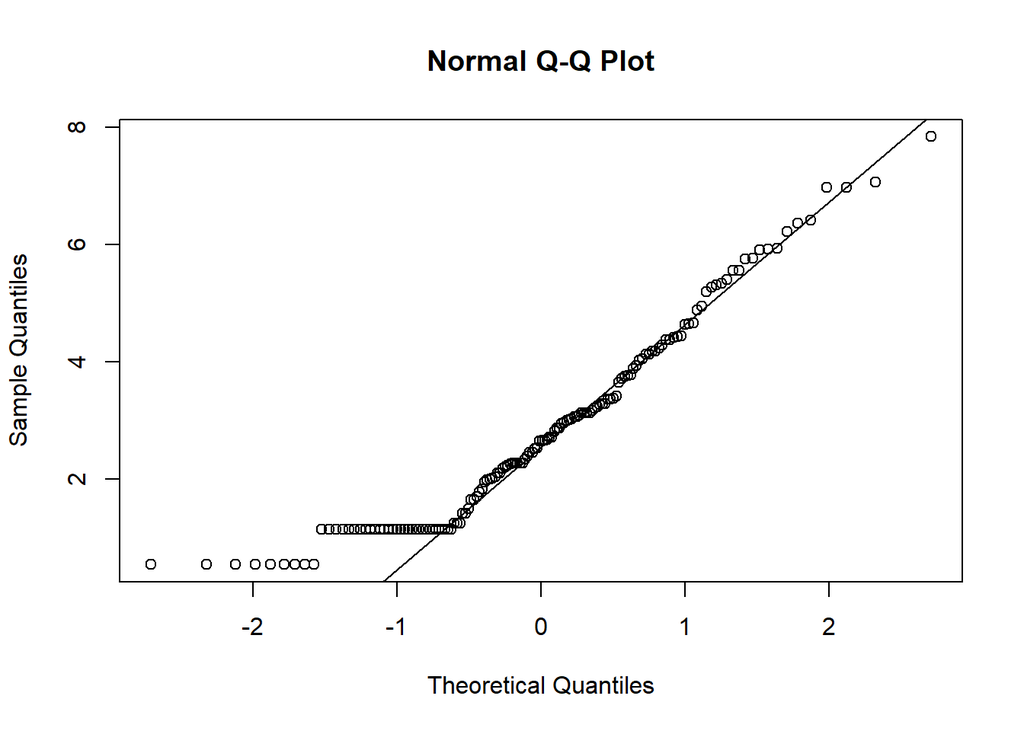

```
## [1] "Alpha: 0.931435286253881"
## [1] "G.6: 0.959472421437321"
## [1] "Omega H asymptotic: 0.931756413705877"
## [1] "Omega Total: 0.932582211254278"
##
## =================
##  RELIABILITY with 4 factors in A
```

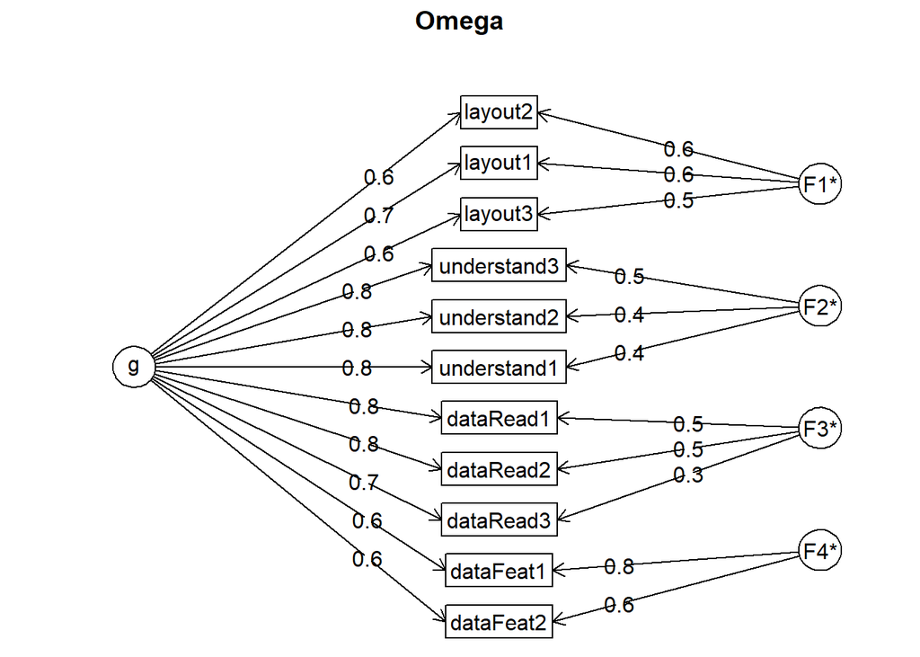

```
## [1] "Alpha: 0.931435286253881"
## [1] "G.6: 0.959472421437321"
## [1] "Omega H asymptotic: 0.842291505487646"
## [1] "Omega Total: 0.969556617193587"
##
## Model Test User Model:
##
##   Test statistic                                85.831
##   Degrees of freedom                                38
##   P-value                                        0.000
##
## User Model versus Baseline Model:
##
##   Comparative Fit Index (CFI)                    0.966
##
## Root Mean Square Error of Approximation:
##
##   RMSEA                                          0.092
##
## DETAILS
## =================
##                                 Tst_-A
## npar                            39.000
## fmin                             0.290
## chisq                           85.831
## df                              38.000
## pvalue                           0.000
## baseline.chisq                1457.841
## baseline.df                     55.000
## baseline.pvalue                  0.000
## cfi                              0.966
## tli                              0.951
## cfi.robust                       0.966
## tli.robust                       0.951
## nnfi                             0.951
## rfi                              0.915
## nfi                              0.941
## pnfi                             0.650
## ifi                              0.966
## rni                              0.966
```

[output cut: 39 more lines]

```
##
## [[2]]
## [1] "B"
##
## [[3]]
## [1] "C"
##
## [1] "B"
##
## =================
##  NORMALITY in B
##
##  #### Shapiro in B
##
##  #### Multivariate normality in B
```

```
##
## =================
##  MISSING DATA IN in B
## No missing values found in the_data.
##
##  Multiple Imputation for missing values in B
##
## =================
##  FACTORABILITY in B
##
##  #### Bartlett in B
## The p value is below 0.05. We are good to continue.
##
## $chisq
## [1] 1442.611
##
## $p.value
## [1] 1.506608e-265
##
## $df
## [1] 55
##
##
##  #### KMO in B
## The overall measure of sampling adequacy is:  0.904249415252045
##
## The sampling adequacy is above 0.7. We are generally good.
```

```
## Parallel analysis suggests that the number of factors =  4  and the number of components =  NA
## Call: fa.parallel(x = corrMatrix, n.obs = observations, fa = "fa",
##     main = "Scree plots with parallel analysis", n.iter = 100,
##     error.bars = TRUE)
## Parallel analysis suggests that the number of factors =  4  and the number of components =  NA
##
##  Eigen Values of
##
##  eigen values of factors
##  [1]  6.62  0.67  0.41  0.22 -0.05 -0.08 -0.14 -0.20 -0.23 -0.29 -0.30
##
##  eigen values of simulated factors
##  [1]  0.46  0.20  0.15  0.11  0.06  0.02 -0.02 -0.06 -0.10 -0.15 -0.20
##
##  eigen values of components
##  [1] 7.00 1.15 0.83 0.56 0.34 0.27 0.24 0.21 0.16 0.12 0.12
##
##  eigen values of simulated components
## [1] NA
##
##
##
## =================
##  RELIABILITY with 1 factors in B
```

```
## Omega_h for 1 factor is not meaningful, just omega_t
```

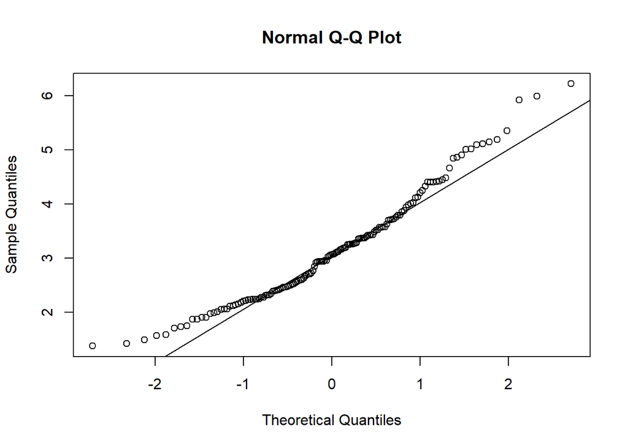

```
## [1] "Alpha: 0.942177739336375"
## [1] "G.6: 0.960624522669553"
## [1] "Omega H asymptotic: 0.942548440124474"
## [1] "Omega Total: 0.942852493893045"
##
## =================
##  RELIABILITY with 4 factors in B
```

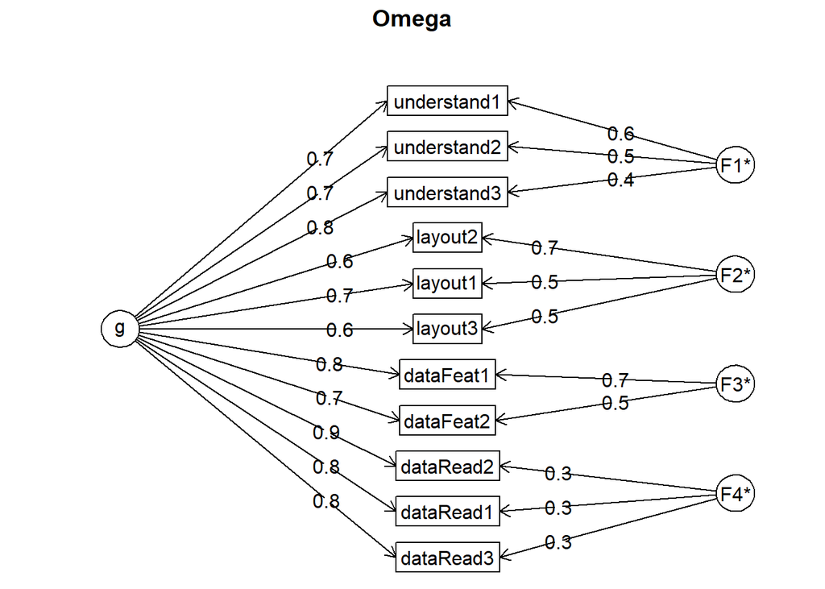

```
## [1] "Alpha: 0.942177739336375"
## [1] "G.6: 0.960624522669553"
## [1] "Omega H asymptotic: 0.866462470446829"
## [1] "Omega Total: 0.971162554007023"
##
## Model Test User Model:
##
##   Test statistic                                57.400
##   Degrees of freedom                                38
##   P-value                                        0.023
##
## User Model versus Baseline Model:
##
##   Comparative Fit Index (CFI)                    0.987
##
## Root Mean Square Error of Approximation:
##
##   RMSEA                                          0.059
##
## DETAILS
## =================
##                                 Tst_-B
## npar                            39.000
## fmin                             0.194
## chisq                           57.400
## df                              38.000
## pvalue                           0.023
## baseline.chisq                1498.291
## baseline.df                     55.000
## baseline.pvalue                  0.000
## cfi                              0.987
## tli                              0.981
## cfi.robust                       0.987
## tli.robust                       0.981
## nnfi                             0.981
## rfi                              0.945
## nfi                              0.962
## pnfi                             0.664
## ifi                              0.987
## rni                              0.987
```

[output cut: 39 more lines]

```
##
## [[2]]
## [1] "B"
##
## [[3]]
## [1] "C"
##
## [1] "C"
##
## =================
##  NORMALITY in C
##
##  #### Shapiro in C
##
##  #### Multivariate normality in C
```

```
##
## =================
##  MISSING DATA IN in C
## No missing values found in the_data.
##
##  Multiple Imputation for missing values in C
##
## =================
##  FACTORABILITY in C
##
##  #### Bartlett in C
## The p value is below 0.05. We are good to continue.
##
## $chisq
## [1] 1391.643
##
## $p.value
## [1] 6.798245e-255
##
## $df
## [1] 55
##
##
##  #### KMO in C
## The overall measure of sampling adequacy is:  0.896531622995882
##
## The sampling adequacy is above 0.7. We are generally good.
```

```
## Parallel analysis suggests that the number of factors =  4  and the number of components =  NA
## Call: fa.parallel(x = corrMatrix, n.obs = observations, fa = "fa",
##     main = "Scree plots with parallel analysis", n.iter = 100,
##     error.bars = TRUE)
## Parallel analysis suggests that the number of factors =  4  and the number of components =  NA
##
##  Eigen Values of
##
##  eigen values of factors
##  [1]  6.43  0.68  0.39  0.30 -0.08 -0.11 -0.13 -0.20 -0.24 -0.29 -0.32
##
##  eigen values of simulated factors
##  [1]  0.46  0.21  0.15  0.10  0.06  0.02 -0.02 -0.06 -0.11 -0.15 -0.21
##
##  eigen values of components
##  [1] 6.83 1.15 0.86 0.66 0.36 0.29 0.22 0.20 0.15 0.14 0.13
##
##  eigen values of simulated components
## [1] NA
##
##
##
## =================
##  RELIABILITY with 1 factors in C
```

```
## Omega_h for 1 factor is not meaningful, just omega_t
```

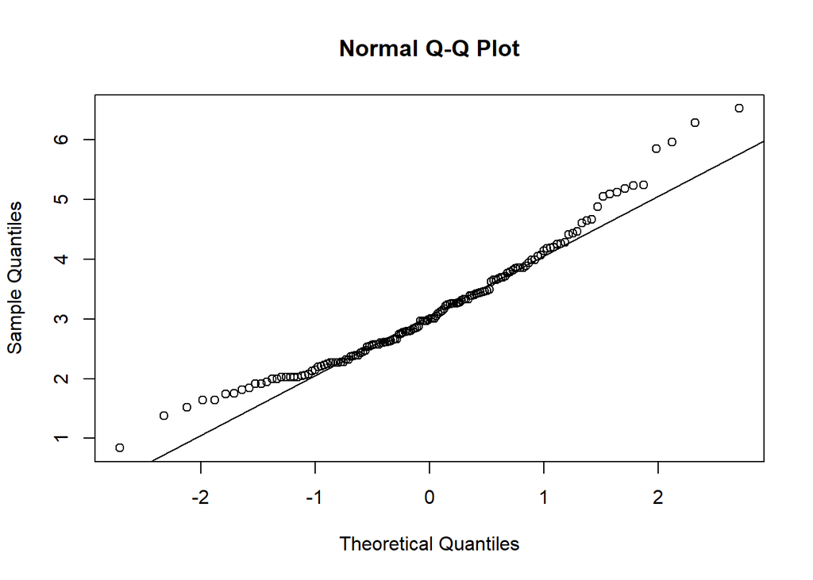

```
## [1] "Alpha: 0.938102493249418"
## [1] "G.6: 0.958217581823434"
## [1] "Omega H asymptotic: 0.938645999257676"
## [1] "Omega Total: 0.938894796446465"
##
## =================
##  RELIABILITY with 4 factors in C
```

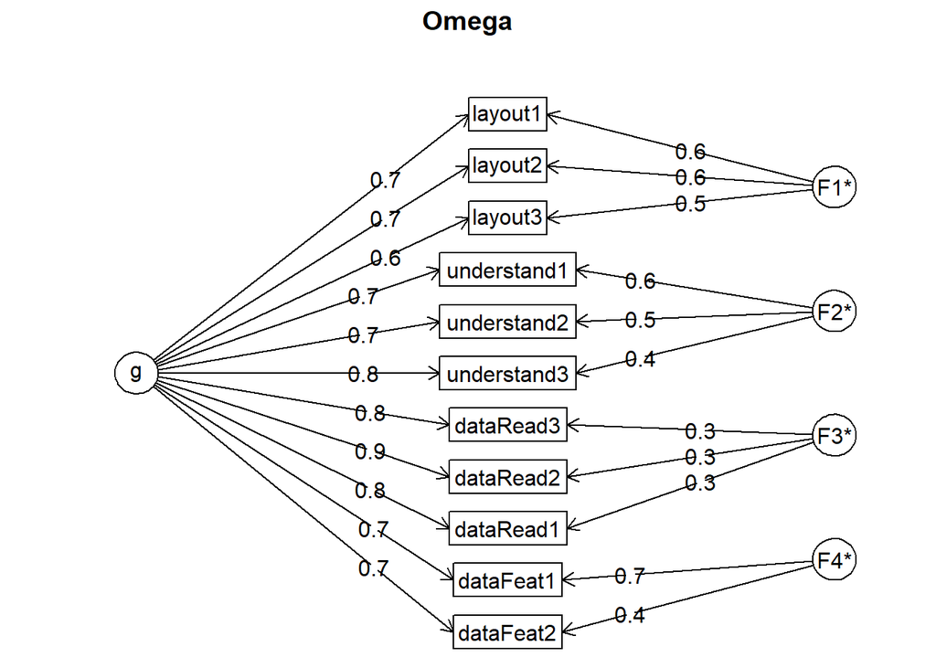

```
## [1] "Alpha: 0.938102493249418"
## [1] "G.6: 0.958217581823434"
## [1] "Omega H asymptotic: 0.853958992195447"
## [1] "Omega Total: 0.96930054579469"
##
## Model Test User Model:
##
##   Test statistic                                59.882
##   Degrees of freedom                                38
##   P-value                                        0.013
##
## User Model versus Baseline Model:
##
##   Comparative Fit Index (CFI)                    0.984
##
## Root Mean Square Error of Approximation:
##
##   RMSEA                                          0.062
##
## DETAILS
## =================
##                                 Tst_-C
## npar                            39.000
## fmin                             0.202
## chisq                           59.882
## df                              38.000
## pvalue                           0.013
## baseline.chisq                1445.355
## baseline.df                     55.000
## baseline.pvalue                  0.000
## cfi                              0.984
## tli                              0.977
## cfi.robust                       0.984
## tli.robust                       0.977
## nnfi                             0.977
## rfi                              0.940
## nfi                              0.959
## pnfi                             0.662
## ifi                              0.984
## rni                              0.984
```

[output cut: 22 more lines]

```
## rmr_nomean                       0.085
## srmr                             0.031
## srmr_bentler                     0.031
## srmr_bentler_nomean              0.033
## crmr                             0.033
## crmr_nomean                      0.036
## srmr_mplus                       0.031
## srmr_mplus_nomean                0.033
## cn_05                          132.939
## cn_01                          152.164
## gfi                              0.969
## agfi                             0.937
## pgfi                             0.478
## mfi                              0.929
## ecvi                             0.932
```

```r
write.csv(reliab_df,file=(paste("generatedData-CFA/reliability-global-by-stimuli.csv", sep="")))
```

```r
# build a model for a latent trait and 4 factors

# Create a string for the overall readability factor
overall_readability <- paste(unlist(Readability_factors), collapse = " + ")

# Create strings for each individual factor
factor_strings <- lapply(names(Readability_factors), function(factor_name) {
  paste(factor_name, " =~ ", paste(unlist(Readability_factors[[factor_name]]), collapse = " + "))
})

# Combine overall and individual factor strings
global_model_string <- c("readability =~ ", overall_readability, factor_strings)
global_model_string <- paste(global_model_string, collapse = "\n")
print(global_model_string)

global_fit <- cfa(global_model_string, data = grp_data, missing = "fiml", group = "stimulus")

omegaFromSem(global_fit,m=corrFiml,flip=TRUE,plot=TRUE)
# library(sem) # for omega
# omegaFromSem(global_fit,plot=TRUE)
```